# Final_Regression

## House Price Prediction

Name: Jeyakumar Sriram

Class: DAAA/FT/2A/01

Admin No.: 22146181

Module Code: ST1511

### Objective

Use Supervised Learning to build a model that can predict house prices in the US given its details

### Background Info

In the US, there are many types of houses for various prices. Usually houses that are better furnished or bigger are priced higher. But their location might matter too.

### The Dataset

| Variable | Meaning |
| --- | --- |
| House ID | Unique house identifier ranging from 0 to 544 |
| City | Which city the house is located |
| House Area | Size of the house in square meters |
| No. of Bedrooms | How many bedrooms in the house |
| No. of Toilets | How many toilets in the house |
| Stories | The number of stories in the house |
| Renovation Status | How well the house is renovated |
| Price | The price of the house in US dollars |

Total Rows: 545

Features: 7

Target: Price

Features: Remaining Columns

```python
# Fundamentals
import pandas as pd
import numpy as np
import seaborn as sns
import matplotlib.pyplot as plt

# Preprocessing

from sklearn.model_selection import train_test_split
from sklearn.preprocessing import (
    StandardScaler, OrdinalEncoder,FunctionTransformer)
from sklearn.compose import ColumnTransformer

# Models
from sklearn.ensemble import( RandomForestRegressor, GradientBoostingRegressor,
                             ExtraTreesRegressor, AdaBoostRegressor)
from sklearn.linear_model import LinearRegression, Ridge, ElasticNet,Lasso
from sklearn.neighbors import KNeighborsRegressor
from sklearn.svm import SVR
from sklearn.gaussian_process import GaussianProcessRegressor
from sklearn.dummy import DummyRegressor
# Tuning
from sklearn.model_selection import GridSearchCV, RandomizedSearchCV

# Metrics and Others
from sklearn.model_selection import cross_validate,learning_curve
from sklearn.metrics import  r2_score
from sklearn.pipeline import Pipeline
```

### Exploratory Data Analysis

```python
df = pd.read_csv("../ST1511 AIML-CA1-datasets/housing_dataset.csv")
print(df.isnull().sum())
df.describe()
```

```
House ID             0
City                 0
House Area (sqm)     0
No. of Bedrooms      0
No. of Toilets       0
Stories              0
Renovation Status    0
Price ($)            0
dtype: int64
```

|  | House ID | House Area (sqm) | No. of Bedrooms | No. of Toilets | Stories | Price ($) |
| --- | --- | --- | --- | --- | --- | --- |
| count | 545.00000 | 545.000000 | 545.000000 | 545.000000 | 545.000000 | 5.450000e+02 |
| mean | 272.00000 | 515.054128 | 2.965138 | 1.286239 | 1.805505 | 4.766729e+05 |
| std | 157.47222 | 217.014102 | 0.738064 | 0.502470 | 0.867492 | 1.870440e+05 |
| min | 0.00000 | 165.000000 | 1.000000 | 1.000000 | 1.000000 | 1.750000e+05 |
| 25% | 136.00000 | 360.000000 | 2.000000 | 1.000000 | 1.000000 | 3.430000e+05 |
| 50% | 272.00000 | 460.000000 | 3.000000 | 1.000000 | 2.000000 | 4.340000e+05 |
| 75% | 408.00000 | 636.000000 | 3.000000 | 2.000000 | 2.000000 | 5.740000e+05 |
| max | 544.00000 | 1620.000000 | 6.000000 | 4.000000 | 4.000000 | 1.330000e+06 |

No null values found here. House area and price seem to have a large range.

### Univariate Analysis

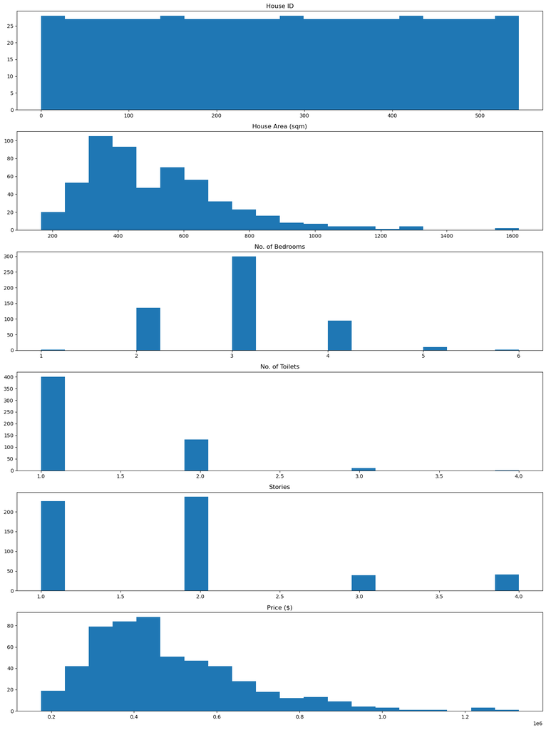

```python
new_df = df.drop(columns=["City","Renovation Status"])
fig,ax = plt.subplots(len(new_df.columns),1,figsize=(15,20))
for i,col in enumerate(new_df.columns):
    ax[i].hist(new_df[col],bins=20)
    ax[i].set_title(col)
plt.tight_layout()
plt.show()
```

All numeric columns are pretty ok but maybe need log transform it to fix the right skew. then need standard scaler all numeric to make it std 1.

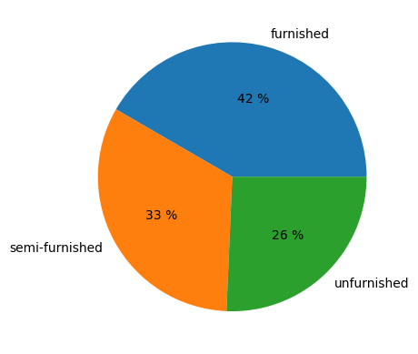

```python
plt.pie(x=df["Renovation Status"].value_counts(),labels=df["Renovation Status"].unique(), autopct="%.0f %%")
plt.show()
```

Three possible values here. Categories are pretty balanced which is good.

### Bivariate Analysis

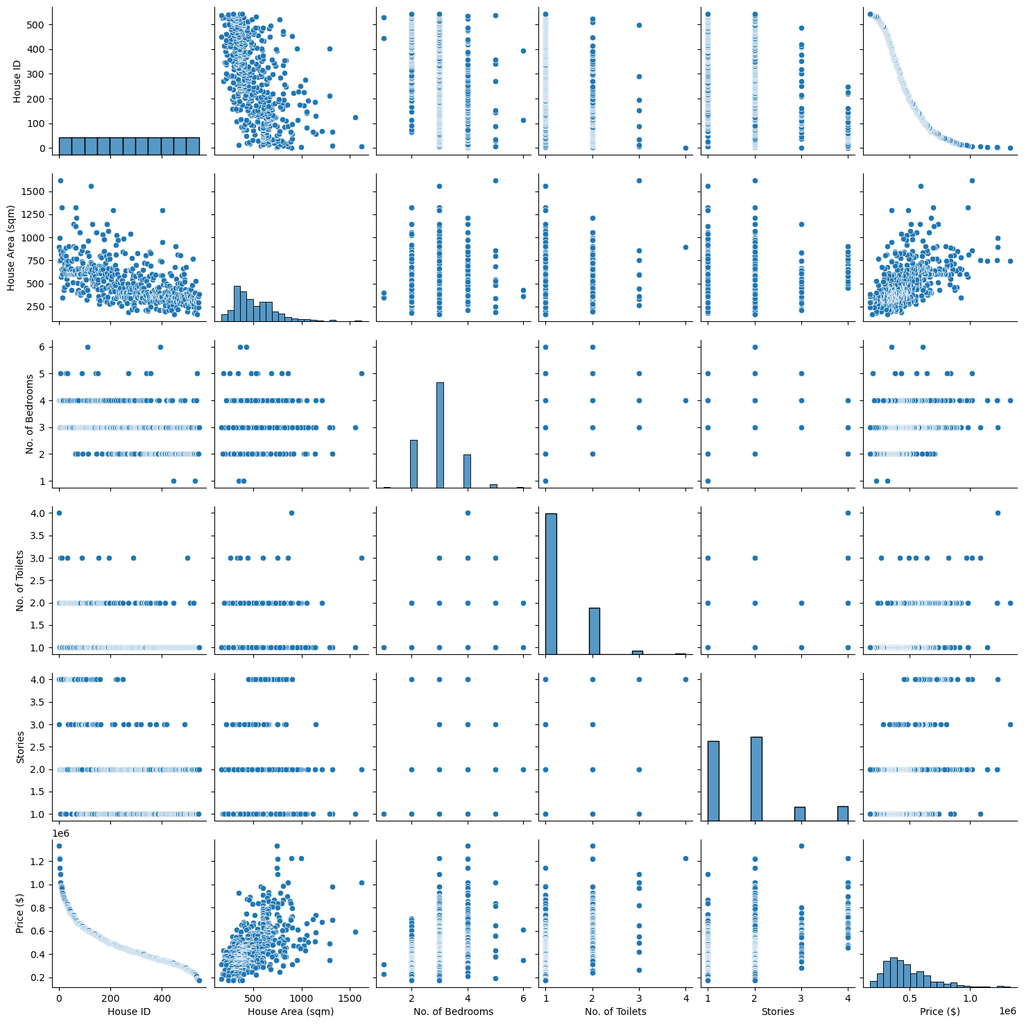

```python
sns.pairplot(df)
```

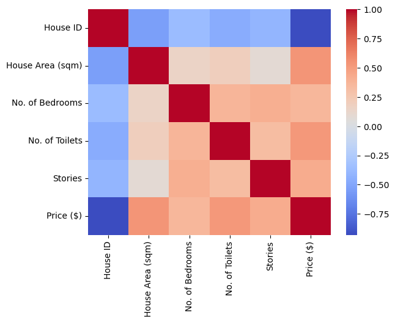

```python
sns.heatmap(df.select_dtypes(include="number").corr(),cmap="coolwarm")
plt.show()
```

There seems to be some correlation between price and house area and no of toilets but nothing substantial.

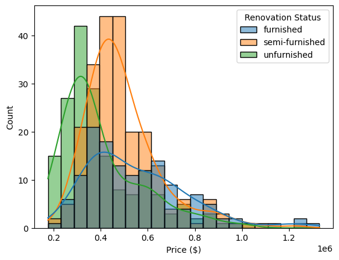

```python
sns.histplot(data=df,x="Price ($)",hue="Renovation Status",kde=True)
```

Unfurnished houses seems to be lower priced. Furnished houses have a large range but at higher prices they are more prevalent. This feature is ordinal as furnishing is better

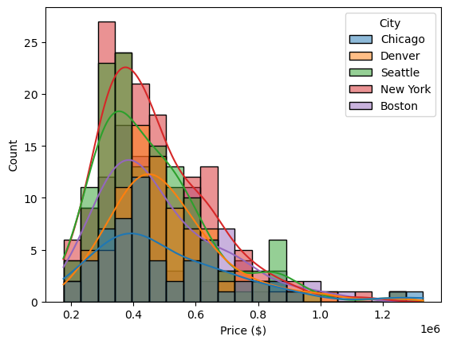

```python
sns.histplot(data=df,x="Price ($)",hue="City",kde=True)
```

Doesn't seem to say anything. Afraid this might just add noise.

#### Summary

| Column | Problem | Transformation Needed |
| --- | --- | --- |
| houseid | useless | remove |
| city | categorical | one hot encoding |
| house area | skewed | log transform /standardise |
| bedrooms | looks fine | log transform /standardise |
| toilets | looks fine | log transform /standardise |
| stories | looks fine | log transform /standardise |
| renovation status | categorical | ordinal encoding |
| price | very large/skewed | log transform /standardise |

### Feature Engineering

there is no imbalance in the data. So no need complex preprocessing. I will just go to splitting data and creating the pipeline. I will do ordinal and one hot encoding here because might have problems in cross validation if data set is small and some categories are not seem by the model

```python
X = df.iloc[:,1:-1]
y = (df["Price ($)"]/1000)# change units
enc = OrdinalEncoder(categories=[['unfurnished', 'semi-furnished', 'furnished']])
X["Renovation Status"]= enc.fit_transform(X["Renovation Status"].values.reshape(-1,1))
X["Renovation Status"] = X["Renovation Status"].astype(int)
# dont want decimal cuz smote might create data like 1.5\
X = pd.get_dummies(X,columns=["City"])

X_train,X_test,y_train,y_test = train_test_split(X,y,train_size=0.80,random_state=99)
features = X_train.columns
```

#### Creating Pipeline

Need reuse later

```python
from sklearn import set_config
def Pipe(name,model):
  set_config(transform_output="pandas")
  pipe = Pipeline([
      ("preprocessing",
          ColumnTransformer([
                          ("num",FunctionTransformer(lambda x: np.log(x.astype(int)+1)),[0,1,2,3]),
                          ("scale",StandardScaler(),[0,1,2,3])
                          ])),
          (name,model)
    ])
  return pipe
```

#### Models to Use

I just select the models available on sklearn to do some intial testing

```python
models = [
    ("DummyRegressor", DummyRegressor()),
    ("AdaBoostRegressor", AdaBoostRegressor()),
    ("Elasticnet", ElasticNet()),
    ("ExtraTreesRegressor", ExtraTreesRegressor()),
    ("GaussianProcessRegressor", GaussianProcessRegressor()),
    ("GradientBoosting", GradientBoostingRegressor()),
    ("KNeighbors", KNeighborsRegressor()),
    ("Lasso", Lasso()),
    ("LinearRegression", LinearRegression()),
    ("RandomForest", RandomForestRegressor()),
    ("Ridge", Ridge()),
    ("SVR", SVR())
]
```

#### Scoring

- MAE = $\frac{1}{n}\sum_{i=1}^n|x_i-x|$ Basically the absolute difference between the predicted and actual values, averaged
- R2: 1 - (sum of squared residuals)/(total sum of squares) Basically tells you how well the model predicts a outcome.
- MAPE: Similiar to MAE but percentage instead

I will be using r2 primarily as it ranges from 0 to 1 where negative values mean the model predicts worse than a constant function that predicts mean.

In this project I will focus on maximising r^2 as it is easier to interpret

```python
results = []
for name, model in models:
    pipe = Pipe(name, model)
    pipe.fit(X_train,y_train)
    score = cross_validate(pipe, X_train, y_train, cv=5, scoring={
        'mae': "neg_mean_absolute_error",
        'r2': 'r2',
        'mape': 'neg_mean_absolute_percentage_error'
    })
    needed = {
        "name": name,
        "mse": np.mean(score["test_mae"])*-1,
        "r2": np.mean(score["test_r2"]),
        "mape": np.mean(score["test_mape"]*-1)
    }
    results.append(needed)

pd.DataFrame(results)
```

|  | name | mse | r2 | mape |
| --- | --- | --- | --- | --- |
| 0 | DummyRegressor | 140.800434 | -1.160832e-02 | 0.325305 |
| 1 | AdaBoostRegressor | 106.413223 | 4.072745e-01 | 0.250428 |
| 2 | Elasticnet | 97.381684 | 4.507505e-01 | 0.220367 |
| 3 | ExtraTreesRegressor | 111.444698 | 2.457295e-01 | 0.245081 |
| 4 | GaussianProcessRegressor | 27701.871146 | -1.973870e+06 | 42.476912 |
| 5 | GradientBoosting | 97.160816 | 4.827062e-01 | 0.216623 |
| 6 | KNeighbors | 100.722470 | 4.089147e-01 | 0.221861 |
| 7 | Lasso | 94.658282 | 4.824005e-01 | 0.210481 |
| 8 | LinearRegression | 94.050631 | 4.879178e-01 | 0.210304 |
| 9 | RandomForest | 101.749604 | 4.193686e-01 | 0.227289 |
| 10 | Ridge | 94.420238 | 4.855194e-01 | 0.210020 |
| 11 | SVR | 129.392713 | 3.680742e-02 | 0.272519 |

GaussianProcess and SVR are clearly poor models. Among the remaining, I want to further investigate the learning curves of RandomForest, Gradient Boosting, ElasticNET, Ridge, and Lasso I dont want LinearRegression as it is very similiar to Lasso and Ridge

#### Compare Learning Curve

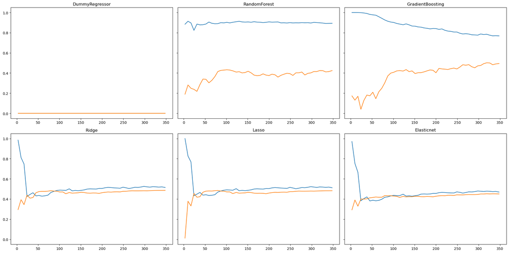

```python
test_models = [("DummyRegressor",DummyRegressor()),("RandomForest", RandomForestRegressor()),
        ("GradientBoosting", GradientBoostingRegressor()),("Ridge",Ridge()),
         ("Lasso",Lasso()),("Elasticnet",ElasticNet())]
fig,ax=plt.subplots(2,3,figsize=(20,10),sharey=True)
score_df = []
for i, (name,model) in enumerate(test_models):
  pipe = Pipe(name,model)
  pipe.fit(X_train,y_train)
  sizes, training_scores, testing_scores = learning_curve(estimator= pipe, X=X_train, y= y_train, cv=5, scoring='r2', train_sizes=np.linspace(0.01, 1.0, 50))
  testing_scores[testing_scores<0] =0 # set neg values to 0
  score_df = pd.DataFrame({"size":(sizes),"train":np.mean(training_scores,axis=1),"test":np.mean(testing_scores,axis=1)})
  row = i//3
  col = i%3
  ax[row,col].plot(score_df["size"],score_df["train"],label = "train")
  ax[row,col].plot(score_df["size"],score_df["test"],label="test")
  ax[row,col].set_title(name)
plt.tight_layout()
plt.show()
```

Random forest and Gradient Boosting seem to be overfitted as the testing curve is way lower than the training one.

Remaining 3 are ptretty good. At the bieggining they are abit shaky because data is sparse and it can be unpredictable.

Overall, I will try tuning ElasticNet, Lasso and Ridge

#### Hyperparam Tuning

First I will do RandomizedSearchCV on the 3 and then based on the results select 1 to do GridSearchCV

```python
testing = [
 ("Ridge", Ridge(max_iter=10000)),
  ("Lasso",Lasso(max_iter=100000)),
  ("ElasticNet", ElasticNet(max_iter=10000))]
params = [
    {
        'Ridge__alpha': [0.001, 0.01, 0.1, 0.5, 1.0, 10.0, 100.0],
        'Ridge__fit_intercept': [True, False],
        'Ridge__solver': ['auto', 'svd', 'cholesky', 'lsqr', 'sparse_cg', 'sag', 'saga']
    },
    {
        'Lasso__alpha': [0.001,0.01, 0.1, 0.5, 1.0, 10.0, 100.0],
        'Lasso__fit_intercept': [True, False],
        'Lasso__selection': ['cyclic', 'random']
    },
    {
        'ElasticNet__alpha':[0.001,0.01, 0.1, 0.5, 1.0, 10.0, 100.0],
        'ElasticNet__l1_ratio':np.arange(0.1,1,0.1)
    }
]
best_models = []
for i, (name,model) in enumerate(testing):
  pipe = Pipe(name,model)
  rand_search = RandomizedSearchCV(pipe,params[i] , cv=5, return_train_score=False,scoring="r2")
  rand_search.fit(X_train, y_train)
  best_models.append(rand_search.best_estimator_)
  print(name,"\n",rand_search.best_params_,"\n", rand_search.best_score_)
```

```
Ridge
 {'Ridge__solver': 'sag', 'Ridge__fit_intercept': True, 'Ridge__alpha': 0.001}
 0.48807046524989917
Lasso
 {'Lasso__selection': 'cyclic', 'Lasso__fit_intercept': True, 'Lasso__alpha': 0.5}
 0.4841535773870012
ElasticNet
 {'ElasticNet__l1_ratio': 0.4, 'ElasticNet__alpha': 0.001}
 0.48815080294941443
```

```python
pipe = Pipe("Ridge",Ridge(max_iter=10000))
rand_search = GridSearchCV(pipe,{
        'Ridge__alpha': [0.0001,0.001, 0.01, 0.1, 0.5, 1.0, 10.0, 100.0,1000.0],
        'Ridge__fit_intercept': [True, False],
        'Ridge__solver': ['auto', 'svd', 'cholesky', 'lsqr', 'sparse_cg', 'sag', 'saga']
    } , cv=5, return_train_score=False,scoring="r2")
rand_search.fit(X_train, y_train)
print(name,"\n",rand_search.best_params_,"\n", rand_search.best_score_)
```

[output not shown]

Very slightly better than last time. I will use this for final scoring

### Final Evaluation

```python
pipe = Pipe("Dummy",DummyRegressor())
pipe.fit(X_train,y_train)
y_pred = pipe.predict(X_test)
print("r2 score: ",r2_score(y_test,y_pred))
```

```
r2 score:  -0.00017835428650836427
```

```python
y_pred = rand_search.best_estimator_.predict(X_test)
print("r2", r2_score(y_test,y_pred))
```

```
r2 0.6636299011390265
```

```python
results = []
for i,v in enumerate(rand_search.best_estimator_.named_steps["Ridge"].feature_names_in_):
    results.append({"Feature":v,"Coeff":rand_search.best_estimator_.named_steps["Ridge"].coef_[i]})
pd.DataFrame(results)
```

|  | Feature | Coeff |
| --- | --- | --- |
| 0 | num__House Area (sqm) | 236.883450 |
| 1 | num__No. of Bedrooms | 415.368746 |
| 2 | num__No. of Toilets | -82.036217 |
| 3 | num__Stories | -133.350438 |
| 4 | scale__House Area (sqm) | -11.146212 |
| 5 | scale__No. of Bedrooms | -57.018598 |
| 6 | scale__No. of Toilets | 71.634121 |
| 7 | scale__Stories | 77.938099 |